# CA

# Vadilating

## comparing **total_disconnections and est_disconnections**

In previous aggregating step, aggregating the disconnection data by county, utility company, year, and month.

- total_disconnections: the unweighted sum of disconnections reported within each group.
- est_disconnections: the weighted sum, using the ratio to estimate each ZIP’s contribution to the county.

```r
print(paste("rows - unweighted total(sum of number_of_disconnections):", sum(CA_county_agg$total_disconnections)))
```

```
## [1] "rows - unweighted total(sum of number_of_disconnections): 1461165"
```

```r
print(paste("rows - weighted total(est_disconnection) :", sum(CA_county_agg$est_disconnections)))
```

```
## [1] "rows - weighted total(est_disconnection) : 1455350.69320984"
```

```r
print(paste("Difference (impact of weighting):", sum(CA_county_agg$difference)))
```

```
## [1] "Difference (impact of weighting): 5814.30679015536"
```

> **Relative difference**

> To contextualize this shift, I calculated the **relative difference** as a percentage of the unweighted total:

```r
relative_diff_socal <-
  sum(CA_county_agg$difference) / sum(CA_county_agg$total_disconnections)* 100

print(paste("Relative Difference (%):", round(relative_diff_socal, 2), "%"))
```

```
## [1] "Relative Difference (%): 0.4 %"
```

The **0.4% relative difference** indicates that applying the ZIP-to-county weighting introduces **minimal deviation** from the raw totals.

## Evaluation Metrics

In this section, I’m gonna to **Calculate Evaluation Metrics**, which quantify the estimation error across all grouped observations (by county, month, and utility):

MAE (Mean Absolute Error): mean of absolute differences between total_disconnections and est_disconnections - MAE is not a normalized metric and is dependent on the scale of the data. This means that an MAE value of 10 might be considered good for predicting millions, but poor for predicting values in the range of 2 digits.

$$\text{Mean Absolute Error} = \frac{1}{n} \sum_{i=1}^{n} \left|
\text{total_disconnections}_i - \text{est_disconnections}_i \right|$$

- MAE value range is 0 from infinity, therefore, less than 1 indicting good accuracy.

MAPE (Mean Absolute Percentage Error):

the percentage equivalent of mean absolute error (MAE), measuring the accuracy between total_disconnections and est_disconnections

$$\text{Mean Percentage Error} = \frac{1}{n} \sum_{i=1}^{n} \left(
\frac{\text{total_disconnections} -
\text{est_disconnections}_i}{\text{total_disconnections}_i} \right)
\times 100$$

> [Montaño, Juan, and Palmer et al](https://www.researchgate.net/publication/257812432_Using_the_R-MAPE_index_as_a_resistant_measure_of_forecast_accuracy). suggest that a MAPE below 20% indicates good accuracy.

> In general, the MAPE across California State remains under this 20% threshold, and 1.33% MAPE value represents high accuracy across California in county level.

```r
mae_CA <- mean(CA_county_agg$mae, na.rm = TRUE)
mape_CA <- mean(CA_county_agg$mape, na.rm = TRUE)  # percentage
rmse_CA <- sqrt(mean((CA_county_agg$total_disconnections - CA_county_agg$est_disconnections)^2, na.rm = TRUE))

print(paste("MAE:", round(mae_CA, 2)))
```

```
## [1] "MAE: 2.32"
```

```r
print(paste("MAPE (%):", round(mape_CA, 2)))
```

```
## [1] "MAPE (%): 1.33"
```

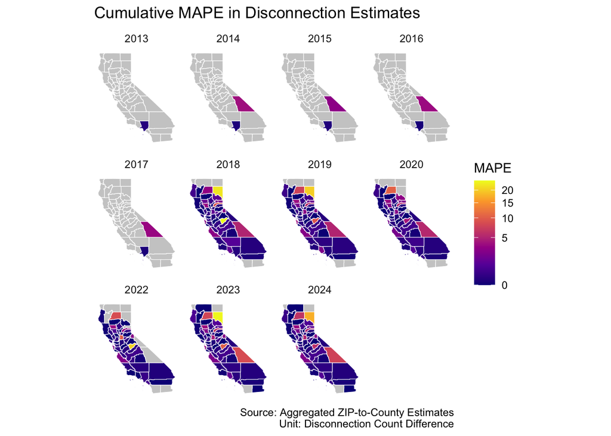

```r
# Step 1: make sure each year have County
county_year_grid_CA <- expand_grid(
  NAME = unique(CA_counties$NAME),
  year = unique(CA_county_agg$year)
)

# Step 2: summary error summary
county_error_summary_CA <- CA_county_agg %>%
  group_by(NAME, year) %>%
  summarise(
    total_abs_error = sum(mae, na.rm = TRUE),
    total_disconnections = sum(total_disconnections, na.rm = TRUE),
    total_est_disconnections = sum(est_disconnections, na.rm = TRUE),
    mape = (total_abs_error / total_disconnections) * 100,  # Percent form
    .groups = "drop"
  )

# Step 3: using grid left_join，let no data be NA value
county_error_complete_CA <- county_year_grid_CA %>%
  left_join(county_error_summary_CA, by = c("NAME", "year"))

# Step 4:  join spatial
county_error_map_CA <- CA_counties %>%
  left_join(county_error_complete_CA, by = "NAME")

# Step 5:
ggplot(county_error_map_CA) +
  geom_sf(aes(fill = mape), color = "white") +
  facet_wrap(~ year) +
  scale_fill_viridis_c(option = "plasma", trans = "sqrt", na.value = "grey80") +
  labs(
    title = "Cumulative MAPE in Disconnection Estimates",
    fill = "MAPE",
    caption = "Source: Aggregated ZIP-to-County Estimates\nUnit: Disconnection Count Difference"
  ) +
  theme_minimal() +
      theme(
    axis.text = element_blank(),
    axis.ticks = element_blank(),
    panel.grid = element_blank()
  )
```

# Limitation

- In this study, when aggregating utility data from ZIP code to county levels, it is not feasible to directly validate the accuracy of the estimates.
- As noted by Din and Wilson (2020), when aggregating data, it is unlikely to have point-level information available; otherwise, there would be no need to perform crosswalk processing.
- Although direct validation is not possible, examining differences between estimated and actual counts may reveal additional patterns of utility disconnection rate, which can be further explored through more detailed spatial analysis.

#### MAPE > 20% and MAE > 1 within the zip code level data

— MAPE: the percentage equivalent of mean absolute error (MAE), measuring the accuracy between `total_disconnections` and `est_disconnections`

— mean of absolute differences between `total_disconnections` and `est_disconnections`

MAPE measures percentage error; MAE measures the average absolute difference between actual and estimated disconnections.

– Some small disconnection counts can lead to a large percentage difference (high MAPE). Therefore, we also examine the MAE: a MAE less than 1 indicates a high level of accuracy despite a seemingly large MAPE.

– As we lack point-level data, a precise one-to-one match between `total_disconnections` and `est_disconnections` values at the ZIP code level is not feasible.

> Among 2506 ZIP code-level records, only 20 records (0.79%) showed a MAPE greater than 20% and a MAE greater than 1.

```r
kable(head(
  CA_county_agg  %>% filter(mape > 20 & mae > 1))
  )
```

| NAME | year | month | utility_name | total_disconnections | est_disconnections | avg_disconnection_rate | difference | PCT_DIF | mae | mape |
| --- | --- | --- | --- | --- | --- | --- | --- | --- | --- | --- |
| Lassen County, California | 2018 | Dec | Pacific Gas and Electric Company | 30 | 20.657025 | 15.000000 | 9.342975 | -31.14325 | 9.342975 | 31.14325 |
| Lassen County, California | 2018 | Sep | Pacific Gas and Electric Company | 8 | 6.373491 | 2.666667 | 1.626509 | -20.33136 | 1.626509 | 20.33136 |
| Lassen County, California | 2019 | Apr | Pacific Gas and Electric Company | 7 | 5.519390 | 2.333333 | 1.480610 | -21.15157 | 1.480610 | 21.15157 |
| Lassen County, California | 2019 | May | Pacific Gas and Electric Company | 17 | 12.259166 | 5.666667 | 4.740834 | -27.88726 | 4.740834 | 27.88726 |
| Lassen County, California | 2023 | June | Pacific Gas and Electric Company | 20 | 14.077561 | 5.000000 | 5.922439 | -29.61220 | 5.922439 | 29.61220 |
| Lassen County, California | 2023 | May | Pacific Gas and Electric Company | 36 | 27.860249 | 6.000000 | 8.139751 | -22.61042 | 8.139751 | 22.61042 |

```r
nrow(CA_county_agg  %>% filter(mape > 20 & mae > 1))
```

```
## [1] 20
```

> **Given the absence of point-level disconnection data, this very low error rate demonstrates strong model accuracy at the ZIP code aggregation level.**

# Reference

Din, A., & Wilson, R. (2020). Crosswalking ZIP Codes to Census Geographies: Geoprocessing the U.S. Department of Housing & Urban Development’s ZIP Code Crosswalk Files. *Cityscape: A Journal of Policy Development and Research, 22*(1), 293–298. U.S. Department of Housing and Urban Development. https://www.huduser.gov/portal/periodicals/cityscpe/vol22num1/ch12.pdf

Wilson, R., & Din, A. (2018). Understanding and enhancing the U.S. Department of Housing and Urban Development’s ZIP Code Crosswalk Files. *Cityscape: A Journal of Policy Development and Research, 20*(2), 277–294. https://www.huduser.gov/portal/periodicals/cityscpe/vol20num2/ch16.pdf

Din, A. (2021). New Data Fields for HUD Aggregated USPS Administrative Data on Address Vacancies. *Cityscape*, *23*(3), 283–294. https://www.jstor.org/stable/48636236

Montaño, Juan & Palmer, Alfonso & Sesé, Albert & Cajal, Berta. (2013). Using the R-MAPE index as a resistant measure of forecast accuracy. Psicothema. 25. 500-506. 10.7334/psicothema2013.23.

- https://www.sciencedirect.com/science/article/pii/S1051200419301289#bbr0610
- https://www.vexpower.com/brief/mean-absolute-percentage-error